# CellPoly quick start vignette

### Installation

```r
# method 1
# devtools::install_github("Nanostring-Biostats/CosMx-Analysis-Scratch-Space/_code/cellPoly@Main")

# method 2
# setwd() in Rstudio to the CellPoly directory
# run devtools::install()
```

### Overview

The CellPoly package is designed to facilitate plotting cells’ polygonal boundaries while working in an R session. For each cell, it finds a polygon encompassing its transcripts. This will diverge from segmentation masks, but it will place each transcript in the same cell (ignoring 3-d considerations).

The only necessary input is a data frame of transcript positions, along with the cell IDs they are assigned to.

This vignette demonstrates the use of the CellPoly package to plot [CosMx](https://www.nature.com/articles/s41587-022-01483-z) data. CosMx is a spatial molecular imager for sub-cellular resolution of mRNA transcripts and protein targets. We analyze a subset of a lupus nephritis experiment.

### Preliminaries

First, we load the package and access the example data:

```r
set.seed(0)

library(CellPoly)
data("cosmx_nephritis")
str(cosmx_nephritis)
```

```
#> List of 3
#>  $ transcript_df:'data.frame':   251551 obs. of  4 variables:
#>   ..$ cell_id: chr [1:251551] "c_5_16_3006" "c_5_16_3017" "c_5_16_1233" "c_5_16_3151" ...
#>   ..$ x      : num [1:251551] 3020 1620 1480 2391 2382 ...
#>   ..$ y      : num [1:251551] -2091 -2153 -2216 -2470 -2829 ...
#>   ..$ target : chr [1:251551] "BATF3" "NEAT1" "NEAT1" "MYH11" ...
#>  $ celltype     : Named chr [1:3631] "PCT" "PCT" "PCT" "PCT" ...
#>   ..- attr(*, "names")= chr [1:3631] "c_5_16_28" "c_5_16_51" "c_5_16_2247" "c_5_16_74" ...
#>  $ cellcols     : Named chr [1:35] "darkblue" "#006600" "gold" "#00FF00" ...
#>   ..- attr(*, "names")= chr [1:35] "B-cell" "macrophage" "mast" "mDC" ...
```

```r
transcript_df = cosmx_nephritis$transcript_df
```

### The CellPoly workflow

The only input we need is transcript positions:

```r
head(transcript_df)
```

```
#>         cell_id       x        y target
#> 84  c_5_16_3006 3019.75 -2090.88  BATF3
#> 88  c_5_16_3017 1619.66 -2152.92  NEAT1
#> 90  c_5_16_1233 1479.96 -2215.84  NEAT1
#> 94  c_5_16_3151 2391.18 -2470.42  MYH11
#> 97  c_5_16_1660 2381.84 -2828.73  NEAT1
#> 100 c_5_16_1911 2899.92 -3232.05  NEAT1
```

Note that the CellPoly functions expect the colnames “cell_id”, “x” and “y” to be present.

For this dataset, we also have pre-defined cell types and cell type colors:

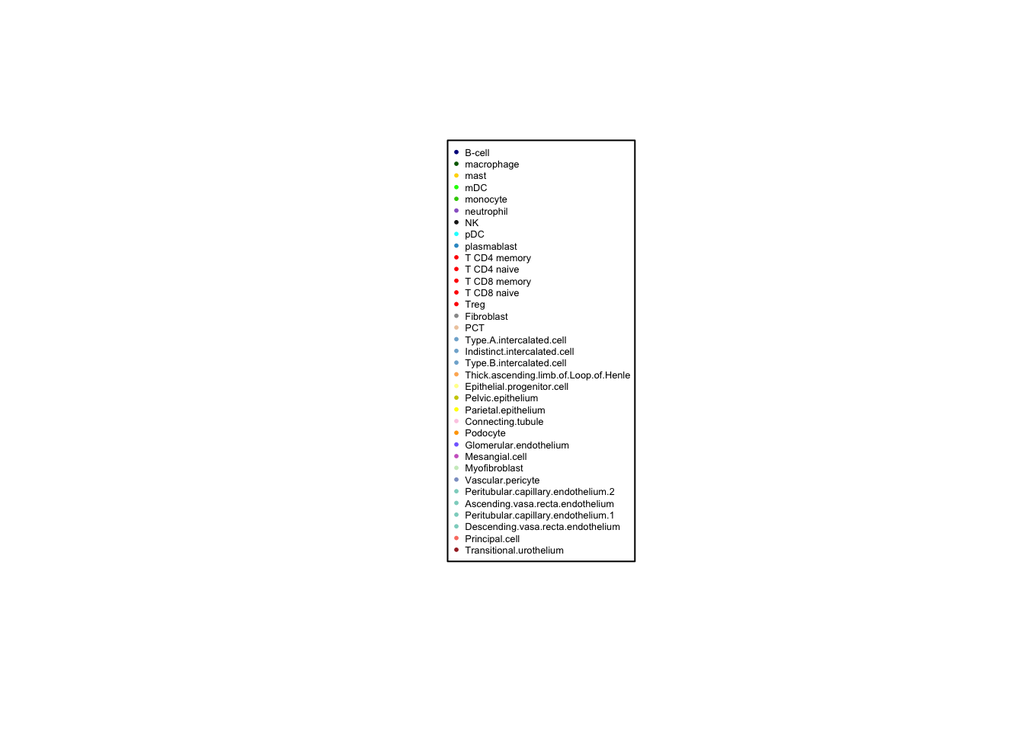

```r
frame()
legend("center",
       pch = 16,
       col = cosmx_nephritis$cellcols,
       legend = names(cosmx_nephritis$cellcols),
       cex = 0.4)
```

We’ll start by initializing an empty polygons object, with elements for each cell in the transcript data frame:

```r
polys <- initPolys(cell_ids = unique(transcript_df$cell_id))
polys[1:3]
```

[output not shown]

We can calculate all polygons at this point:

```r
polys <- cellPolys(polys = polys,
                   transcript_df = transcript_df,
                   type = "chull",   # faster chull, slower/buggy "ahull" also available
                   cell_ids = NULL)

polys[1]
```

```
#> $c_5_16_3006
#>             x        y
#>  [1,] 3060.87 -2130.31
#>  [2,] 3054.58 -2165.94
#>  [3,] 3050.47 -2165.95
#>  [4,] 3042.24 -2165.64
#>  [5,] 2994.58 -2157.02
#>  [6,] 2988.10 -2154.46
#>  [7,] 2969.20 -2138.12
#>  [8,] 2968.49 -2136.83
#>  [9,] 2968.01 -2132.80
#> [10,] 2969.13 -2122.90
#> [11,] 2970.09 -2120.71
#> [12,] 3007.86 -2083.26
#> [13,] 3016.88 -2081.36
#> [14,] 3025.28 -2080.16
#> [15,] 3040.61 -2086.16
#> [16,] 3045.93 -2089.32
#> [17,] 3056.03 -2105.06
#> [18,] 3060.44 -2118.98
#> [19,] 3060.87 -2130.31
```

Now we can plot polygons:

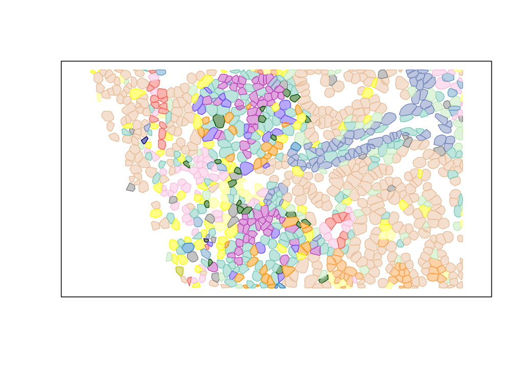

```r
drawPolys(polys,
          cell_ids = NULL, #tempids,
          col = scales::alpha(cosmx_nephritis$cellcols[cosmx_nephritis$celltype[names(polys)]], 0.5),
          border = cosmx_nephritis$cellcols[cosmx_nephritis$celltype[names(polys)]],
          add = FALSE, outputpolys = FALSE, xaxt = "n", yaxt = "n", xlab = "", ylab = "", asp = 1)
```

To finish this example, you might want to plot a couple genes across this view:

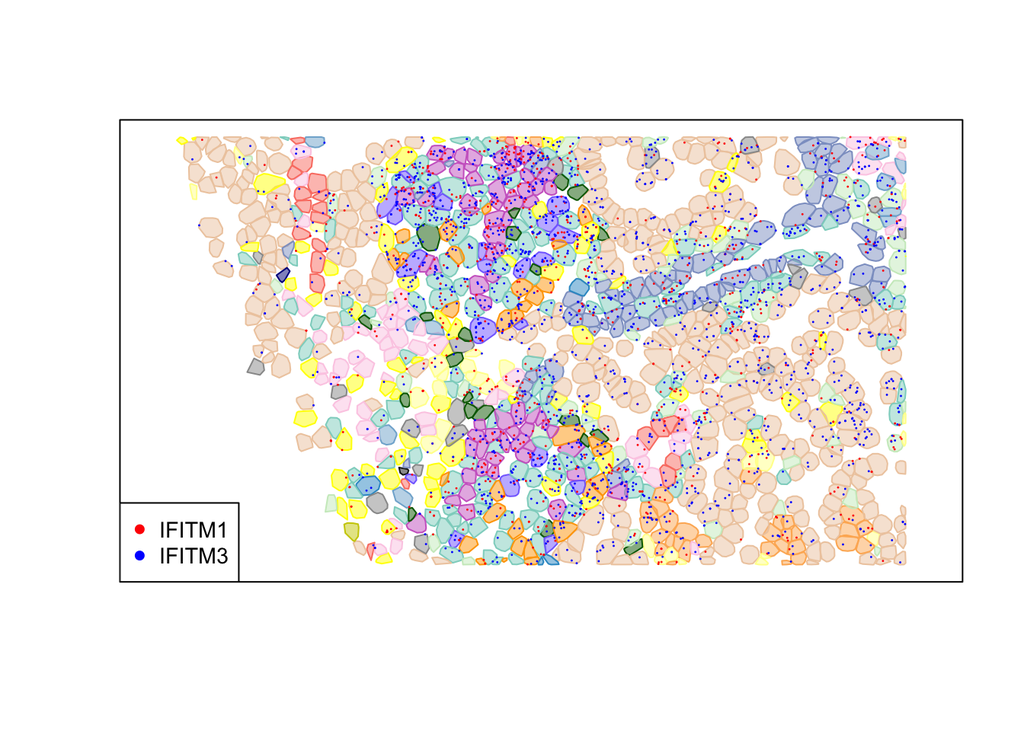

```r
drawPolys(polys,
          cell_ids = NULL, #tempids,
          col = scales::alpha(cosmx_nephritis$cellcols[cosmx_nephritis$celltype[names(polys)]], 0.5),
          border = cosmx_nephritis$cellcols[cosmx_nephritis$celltype[names(polys)]],
          add = FALSE, outputpolys = FALSE, xaxt = "n", yaxt = "n", xlab = "", ylab = "", asp = 1)
# which genes to show and their colors:
genecols = c("IFITM1" = "red",
             "IFITM3" = "blue")
# points for genes:
for (gene in names(genecols)) {
  points(transcript_df[transcript_df$target == gene, c("x", "y")],
         col = genecols[gene],
         pch = 16, cex = 0.2)
}
legend("bottomleft", col = genecols, legend = names(genecols), pch = 16, cex = 0.9)
```

### Inattentive workflow

You can also work with just the drawPolys() function, skipping the cellPolys call:

```
#> deriving 5 cells' polgons
```

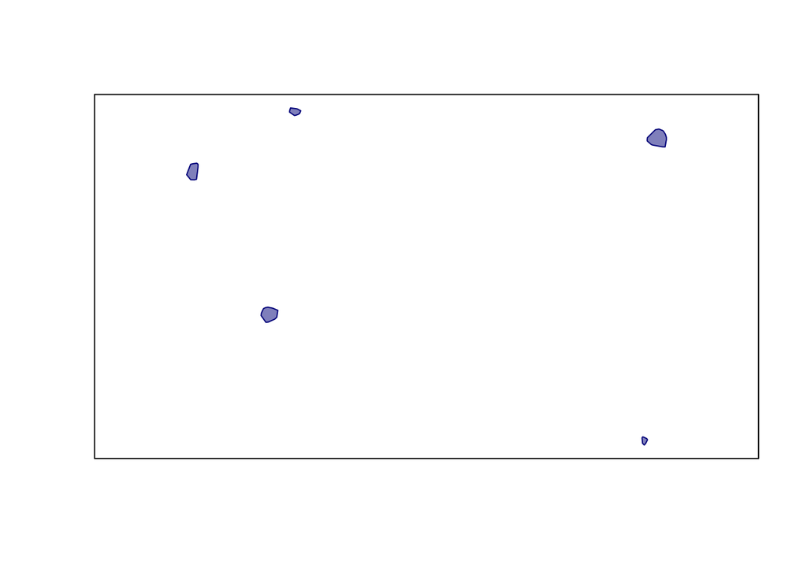

```r
#initialize:
polys <- initPolys(cell_ids = unique(transcript_df$cell_id))

# draw a few polygons, saving them so they don't need to be recalcualted
polys <- drawPolys(polys,
                   cell_ids = names(polys)[c(1,200, 400, 700, 900)],
                   transcript_df = transcript_df,
                   col = "#00008B80", border = "#00008BFF",
                   add = FALSE,
                   outputpolys = TRUE,
                   type = "chull",
                   xaxt = "n", yaxt = "n", xlab = "", ylab = "", asp = 1)
```

```r
# the polys object now have values for the cell ids we specified:
polys[1]
```

```
#> $c_5_16_3006
#>             x        y
#>  [1,] 3060.87 -2130.31
#>  [2,] 3054.58 -2165.94
#>  [3,] 3050.47 -2165.95
#>  [4,] 3042.24 -2165.64
#>  [5,] 2994.58 -2157.02
#>  [6,] 2988.10 -2154.46
#>  [7,] 2969.20 -2138.12
#>  [8,] 2968.49 -2136.83
#>  [9,] 2968.01 -2132.80
#> [10,] 2969.13 -2122.90
#> [11,] 2970.09 -2120.71
#> [12,] 3007.86 -2083.26
#> [13,] 3016.88 -2081.36
#> [14,] 3025.28 -2080.16
#> [15,] 3040.61 -2086.16
#> [16,] 3045.93 -2089.32
#> [17,] 3056.03 -2105.06
#> [18,] 3060.44 -2118.98
#> [19,] 3060.87 -2130.31
```

```r
# but the other cells still have no polys:
polys[2]
```

[output not shown]

```
#> deriving 987 cells' polgons
```

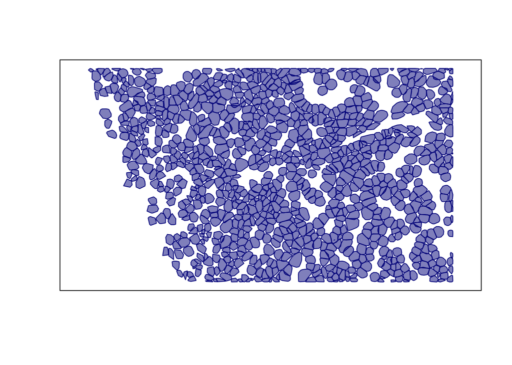

```r
# now draw the rest:
polys <- drawPolys(polys,
                   cell_ids = NULL,
                   transcript_df = transcript_df,
                   col = "#00008B80", border = "#00008BFF",
                   add = FALSE,
                   outputpolys = TRUE,
                   type = "chull",
                   xaxt = "n", yaxt = "n", xlab = "", ylab = "", asp = 1)
```

```r
polys[2]
```

```
#> $c_5_16_3017
#>             x        y
#>  [1,] 1682.16 -2162.80
#>  [2,] 1678.76 -2169.31
#>  [3,] 1676.81 -2172.71
#>  [4,] 1674.45 -2174.54
#>  [5,] 1660.59 -2182.95
#>  [6,] 1657.13 -2184.62
#>  [7,] 1617.92 -2192.88
#>  [8,] 1615.00 -2191.85
#>  [9,] 1606.20 -2185.56
#> [10,] 1605.27 -2184.65
#> [11,] 1591.23 -2168.30
#> [12,] 1590.60 -2149.86
#> [13,] 1593.63 -2139.75
#> [14,] 1597.22 -2129.27
#> [15,] 1611.56 -2117.34
#> [16,] 1623.34 -2115.89
#> [17,] 1628.95 -2115.53
#> [18,] 1656.51 -2114.32
#> [19,] 1667.97 -2120.18
#> [20,] 1672.02 -2124.60
#> [21,] 1677.07 -2132.70
#> [22,] 1678.83 -2136.65
#> [23,] 1681.32 -2143.17
#> [24,] 1682.16 -2162.80
```